# assignment2

## 1. Simulate data

Consider the following production and investment process $j = 1, \cdots, 1000$ firms across $t = 1, \cdots, 10$ periods.

The log production function is of the form:

$$y_{jt} = \beta_0 + \beta_l l_{jt} + \beta_k k_{jt} + \omega_{jt} + \eta_{jt},$$

where $\omega_{jt}$ is an anticipated shock and $\eta_{jt}$ is an ex post shock.

The anticipated shocks evolve as:

$$\omega_{jt} = \alpha \omega_{j, t - 1} + \nu_{jt},$$

where $\nu_{jt}$is an i.i.d. normal random variable with mean 0 and standard deviation $\sigma_\nu$. The ex post shock is an i.i.d. normal random variable with mean 0 and standard deviation $\sigma_{\eta}$.

The product price the same across firms and normalized at 1. The price is normalized at 1. The wage $w_t$ is an i.i.d. exponential of normal random variable with mean 0 and standard deviation $\sigma_w$.

Finally, the capital accumulate according to:

$$K_{j, t + 1} = (1 - \delta) K_{jt} + I_{jt}.$$

We set the parameters as follows:

| parameter | variable | value |
| --- | --- | --- |
| $\beta_0$ | `beta_0` | 1 |
| $\beta_l$ | `beta_l` | 0.2 |
| $\beta_k$ | `beta_k` | 0.7 |
| $\alpha$ | `alpha` | 0.7 |
| $\sigma_\eta$ | `sigma_eta` | 0.2 |
| $\sigma_\nu$ | `sigma_nu` | 0.5 |
| $\sigma_w$ | `sigma_w` | 0.1 |
| $\delta$ | `delta` | 0.05 |

1. Define the parameter variables as above.

```r
rm(list=ls())
beta_0=1
beta_l=0.2
beta_k=0.7
alpha=0.7
sigma_eta=0.2
sigma_nu=0.5
sigma_w=0.1
delta=0.05
```

2. I write a function that returns the log output given $l_{jt}$, $k_{jt}$, $\omega_{jt}$ and $l_{jt}$ under the given parameter values according to the above production function and name it log_production. All the functions in this report are written in “assignment2_function”

Suppose that the labor is determined after $\omega_{jt}$ is observed, but before $\eta_{jt}$ is observed, given the log capital level $k_{jt}$.

3. Derive the optimal log labor as a function of $\omega_{jt}$, $\eta_{jt}$, $k_{jt}$ and $w_t$. I write a function to return the optimal log labor given the variables and parameters and name it log_labor_choice.

As discussed in the class, if there is no additional variation in labor, the coefficient on the labor $\beta_l$ is not identified. Thus, if we generate labor choice from the previous function, $\beta_l$ will not be identified from the simulated data. To see this, we write a modified version of the previous function in which $\omega_{jt}$ is replaced with $\omega_{jt} + \iota_{jt}$, where $\iota_{jt}$ is an optimization error that follows an i.i.d. normal distribution with mean 0 and standard deviation 0.05. That is, the manager of the firm perceives as if the shock is $\omega_{jt} + \iota_{jt}$, even though the true shock is $\omega_{jt}$.

4. Modify the previous function by including $\iota_{jt}$ as an additional input and name it log_labor_choice_error.

Consider an investment process such that:

$$I_{jt} = (\delta + \gamma w_{jt}) K_{jt},$$

where $I_{jt}$ and $K_{jt}$ are investment and capital in level. Set $\gamma=0.1$, i.e., the investment is strictly increasing in $\omega_{jt}$. The investment function should be derived by solving the dynamic problem of a firm. But here, we just specify it in a reduced-form.

5. Define variable $\gamma$ and assign it the value.

```r
gamma=0.1
```

Write a function that returns the investment given $K_{jt}$, $\omega_{jt}$, and parameter values, according to the previous equation, and name it investment_choice.

Simulate the data first using the labor choice without optimization error and second using the labor choice with optimization error. To do so, we specify the initial values for the state variables $k_{jt}$, $\omega_{jt}$ as follows.

6. Draw $k_{j0}$ from an i.i.d. normal distribution with mean 1 and standard deviation 0.5. Draw $\omega_{j0}$ rom its stationary distribution (check the stationary distribution of AR(1) process). Draw a wage. Before simulating the rest of the data, set the seed at 1.

Since $\omega$ follow the normal distribution, and since $\omega_{jt} = \alpha \omega_{j, t - 1} + \nu_{jt},$, and since $\nu$ follow normal distribution, I calculate the variance of omega, and since $\nu_{jt}=\alpha \omega_{j, t - 1} - \omega_{jt}$, then mean of $\nu$ is 0, clearly, the mean of $\omega$ is 0. Thus, the result is $\omega$ follow the normal random variable with mean 0 and standard deviation sqrt(25/51)

```r
library(tibble)
j<-rep(1:1000)
t<-rep(1,1000)
set.seed(1)
k<-rnorm(1000, mean=1, sd=0.5)
#omega=rnorm(1000)*sqrt(25/51)
omega<-rnorm(1000, mean=0, sd=sqrt(25/51))
#wage<- rep(rlnorm(1, meanlog = 0, sdlog = 0.1),1000)
wage<- rep(0.5,1000)

t1<-tibble("j" = j, "t" = t, "k" = k, "omega"=omega, "wage"=wage);t1
```

```
## # A tibble: 1,000 x 5
##        j     t     k   omega  wage
##    <int> <dbl> <dbl>   <dbl> <dbl>
##  1     1     1 0.687  0.795    0.5
##  2     2     1 1.09   0.779    0.5
##  3     3     1 0.582 -0.610    0.5
##  4     4     1 1.80   0.148    0.5
##  5     5     1 1.16   0.0486   0.5
##  6     6     1 0.590 -1.16     0.5
##  7     7     1 1.24   0.568    0.5
##  8     8     1 1.37  -1.34     0.5
##  9     9     1 1.29  -0.873    0.5
## 10    10     1 0.847  0.699    0.5
## # ... with 990 more rows
```

7. Compute the labor and investment choice of period 1. For labor choice, compute both types of labor choices.

```r
t1$iota<-rnorm(1000, mean=0, sd=0.05)

t1$l<-log_labor_choice(t1$omega,t1$k,t1$wage, beta_0, beta_l, beta_k,sigma_eta)

t1$l_error<-log_labor_choice_error(t1$omega,t1$k,t1$wage, t1$iota, beta_0, beta_l, beta_k,sigma_eta)

t1$I<-investment_choice(delta,gamma, t1$omega,exp(t1$k))

t1
```

```
## # A tibble: 1,000 x 9
##        j     t     k   omega  wage     iota      l l_error       I
##    <int> <dbl> <dbl>   <dbl> <dbl>    <dbl>  <dbl>   <dbl>   <dbl>
##  1     1     1 0.687  0.795    0.5 -0.0443   1.72   1.67    0.257
##  2     2     1 1.09   0.779    0.5 -0.0961   2.06   1.94    0.381
##  3     3     1 0.582 -0.610    0.5  0.0810  -0.123 -0.0218 -0.0196
##  4     4     1 1.80   0.148    0.5  0.0260   1.89   1.92    0.391
##  5     5     1 1.16   0.0486   0.5 -0.00279  1.21   1.21    0.176
##  6     6     1 0.590 -1.16     0.5  0.0348  -0.809 -0.766  -0.120
##  7     7     1 1.24   0.568    0.5  0.00268  1.93   1.93    0.370
##  8     8     1 1.37  -1.34     0.5 -0.0655  -0.346 -0.428  -0.330
##  9     9     1 1.29  -0.873    0.5 -0.106    0.165  0.0327 -0.135
## 10    10     1 0.847  0.699    0.5 -0.0104   1.74   1.73    0.280
## # ... with 990 more rows
```

8. Draw ex post shock and compute the output according to the production function for both labor without optimization error and with optimization error.

```r
t1$eta<-rnorm(1000, mean=0, sd=sigma_eta)

t1$y<-log_production(t1$l, t1$k,t1$omega,t1$eta,beta_0, beta_l, beta_k)

t1$y_error<-log_production(t1$l_error, t1$k,t1$omega,t1$eta, beta_0, beta_l, beta_k)

t1
```

```
## # A tibble: 1,000 x 12
##        j     t     k   omega  wage     iota      l l_error       I     eta
##    <int> <dbl> <dbl>   <dbl> <dbl>    <dbl>  <dbl>   <dbl>   <dbl>   <dbl>
##  1     1     1 0.687  0.795    0.5 -0.0443   1.72   1.67    0.257   0.148
##  2     2     1 1.09   0.779    0.5 -0.0961   2.06   1.94    0.381   0.0773
##  3     3     1 0.582 -0.610    0.5  0.0810  -0.123 -0.0218 -0.0196  0.259
##  4     4     1 1.80   0.148    0.5  0.0260   1.89   1.92    0.391  -0.161
##  5     5     1 1.16   0.0486   0.5 -0.00279  1.21   1.21    0.176  -0.321
##  6     6     1 0.590 -1.16     0.5  0.0348  -0.809 -0.766  -0.120   0.187
##  7     7     1 1.24   0.568    0.5  0.00268  1.93   1.93    0.370   0.361
##  8     8     1 1.37  -1.34     0.5 -0.0655  -0.346 -0.428  -0.330  -0.0113
##  9     9     1 1.29  -0.873    0.5 -0.106    0.165  0.0327 -0.135   0.377
## 10    10     1 0.847  0.699    0.5 -0.0104   1.74   1.73    0.280   0.316
## # ... with 990 more rows, and 2 more variables: y <dbl>, y_error <dbl>
```

9. Repeat this procedure for $t = 1, \cdots 10$ by updating the capital and anticipated shocks, and name the resulting data frame df_T.

```r
t1[,c("nu")]<- NA

df_T<-t1
newtibble<-t1  #copy the data of last period

for(i in rep(2:10)){
  t2<-tibble(j=rep(1:1000),t=rep(i,1000))
  K=(1-delta)*exp(newtibble$k)+newtibble$I
  t2$k<-log(K)
  nu=rnorm(1000, mean=0, sd=0.5)
  t2$omega<-alpha*newtibble$omega+nu
  t2$wage<- rep(0.5,1000)
  t2$iota<-rnorm(1000, mean=0, sd=0.05)
  t2$l<-log_labor_choice(t2$omega,t2$k,t2$wage, beta_0, beta_l, beta_k,sigma_eta)
  t2$l_error<-log_labor_choice_error(t2$omega,t2$k,t2$wage, t2$iota, beta_0, beta_l, beta_k,sigma_eta)
  t2$I<-investment_choice(delta,gamma, t2$omega,exp(t2$k))
  t2$eta=rnorm(1000, mean=0,sd=sigma_eta)
  t2$y=log_production(t2$l, t2$k,t2$omega,t2$eta, beta_0, beta_l, beta_k)
  t2$y_error=log_production(t2$l_error, t2$k,t2$omega,t2$eta, beta_0, beta_l, beta_k)
  t2$nu=nu
  newtibble<-t2
  df_T<-rbind(df_T,t2)
}
df_T
```

```
## # A tibble: 10,000 x 13
##        j     t     k   omega  wage     iota      l l_error       I     eta
##    <int> <dbl> <dbl>   <dbl> <dbl>    <dbl>  <dbl>   <dbl>   <dbl>   <dbl>
##  1     1     1 0.687  0.795    0.5 -0.0443   1.72   1.67    0.257   0.148
##  2     2     1 1.09   0.779    0.5 -0.0961   2.06   1.94    0.381   0.0773
##  3     3     1 0.582 -0.610    0.5  0.0810  -0.123 -0.0218 -0.0196  0.259
##  4     4     1 1.80   0.148    0.5  0.0260   1.89   1.92    0.391  -0.161
##  5     5     1 1.16   0.0486   0.5 -0.00279  1.21   1.21    0.176  -0.321
##  6     6     1 0.590 -1.16     0.5  0.0348  -0.809 -0.766  -0.120   0.187
##  7     7     1 1.24   0.568    0.5  0.00268  1.93   1.93    0.370   0.361
##  8     8     1 1.37  -1.34     0.5 -0.0655  -0.346 -0.428  -0.330  -0.0113
##  9     9     1 1.29  -0.873    0.5 -0.106    0.165  0.0327 -0.135   0.377
## 10    10     1 0.847  0.699    0.5 -0.0104   1.74   1.73    0.280   0.316
## # ... with 9,990 more rows, and 3 more variables: y <dbl>, y_error <dbl>,
## #   nu <dbl>
```

10. Check the simulated data by making summary table.

```r
library(knitr)
library(summarytools)
kable(descr(df_T, stats = c("n.valid", "mean", "sd", "min", "max"), transpose = TRUE), format = "markdown")
```

|  | N.Valid | Mean | Std.Dev. | Min | Max |
| --- | --- | --- | --- | --- | --- |
| eta | 10000 | 0.0015825 | 0.2001539 | -0.7650371 | 0.7455922 |
| I | 10000 | 0.1793502 | 0.3006526 | -1.2722627 | 3.2975332 |
| iota | 10000 | -0.0000696 | 0.0502883 | -0.1841453 | 0.1715419 |
| j | 10000 | 500.5000000 | 288.6894251 | 1.0000000 | 1000.0000000 |
| k | 10000 | 0.9797900 | 0.5838949 | -1.2822534 | 3.2332312 |
| l | 10000 | 0.9799746 | 1.0965108 | -3.3281023 | 4.9679634 |
| l_error | 10000 | 0.9798876 | 1.0971595 | -3.3765433 | 4.9520674 |
| nu | 9000 | -0.0021155 | 0.4984324 | -2.1513907 | 1.8253882 |
| omega | 10000 | -0.0055826 | 0.7025102 | -2.5894171 | 2.6281307 |
| t | 10000 | 5.5000000 | 2.8724249 | 1.0000000 | 10.0000000 |
| wage | 10000 | 0.5000000 | 0.0000000 | 0.5000000 | 0.5000000 |
| y | 10000 | 1.8778479 | 1.1171035 | -2.4680251 | 6.1228291 |
| y_error | 10000 | 1.8778305 | 1.1169266 | -2.4777133 | 6.1196499 |

## 2. Estimate the parameters

For now, use the labor choice with optimization error.

1. First, simply regress $y_{jt}$ on $l_{jt}$ and $k_{jt}$ using the least square method.

```r
fit1<-lm(formula = y_error ~ l_error + k, data = df_T)
summary(fit1)
```

```
##
## Call:
## lm(formula = y_error ~ l_error + k, data = df_T)
##
## Residuals:
##      Min       1Q   Median       3Q      Max
## -0.73002 -0.14117 -0.00071  0.13743  0.87983
##
## Coefficients:
##             Estimate Std. Error t value Pr(>|t|)
## (Intercept) 0.892542   0.004058 219.966   <2e-16 ***
## l_error     0.997913   0.002396 416.454   <2e-16 ***
## k           0.007599   0.004503   1.688   0.0915 .
## ---
## Signif. codes:  0 '***' 0.001 '**' 0.01 '*' 0.05 '.' 0.1 ' ' 1
##
## Residual standard error: 0.2068 on 9997 degrees of freedom
## Multiple R-squared:  0.9657, Adjusted R-squared:  0.9657
## F-statistic: 1.408e+05 on 2 and 9997 DF,  p-value: < 2.2e-16
```

2. Second, take within-transformation on $y_{jt}$, $l_{jt}$ and $k_{jt}$ and let $\Delta y_{jt}$, $\Delta l_{jt}$ and $\Delta k_{jt}$ denote them. Then, regress $\Delta y_{jt}$ on $\Delta l_{jt}$, and $\Delta k_{jt}$ by the least squares method.

```r
df_T_within<- df_T %>%
  dplyr::group_by(j) %>%
  dplyr::mutate(dy_error=y_error-mean(y_error)) %>%
  dplyr::mutate(dl_error=l_error-mean(l_error)) %>%
  dplyr::mutate(dk=k-mean(k)) %>%
  dplyr::ungroup()

fit2=lm(formula = dy_error ~ -1 + dl_error + dk, data = df_T_within)
summary(fit2)
```

```
##
## Call:
## lm(formula = dy_error ~ -1 + dl_error + dk, data = df_T_within)
##
## Residuals:
##      Min       1Q   Median       3Q      Max
## -0.72450 -0.13285 -0.00244  0.12931  0.77657
##
## Coefficients:
##            Estimate Std. Error t value Pr(>|t|)
## dl_error  0.9910916  0.0029548 335.413   <2e-16 ***
## dk       -0.0009029  0.0127539  -0.071    0.944
## ---
## Signif. codes:  0 '***' 0.001 '**' 0.01 '*' 0.05 '.' 0.1 ' ' 1
##
## Residual standard error: 0.1961 on 9998 degrees of freedom
## Multiple R-squared:  0.9184, Adjusted R-squared:  0.9184
## F-statistic: 5.629e+04 on 2 and 9998 DF,  p-value: < 2.2e-16
```

3. Next, we attempt to estimate the parameters using Olley-Pakes method. Estimate the first-step model of Olley-Pakes method:

$$y_{jt} = \beta_0 + \beta_l l_{jt} + \phi(k_{jt}, I_{jt}) + \eta_{jt},$$

by approximating $\phi_t$ by a kernel function.

Remark that $\phi$ in general depends on observed and unobserved state variables. For this reason, in theory, $\phi$ should be estimated for each period. In this exercise, we assume $\phi$ is common across periods because we know that there is no unobserved state variables in the true data generating process. Moreover, we do not include $w_t$ because we know that it is i.i.d. in the true data generating process. Here, I return the summary of the first stage estimation and plot the fitted values against the data points.

```r
library(np)
bw <- npplregbw(formula=y_error~l_error + k+I|k+I, data = df_T)
```

[output not shown]

[output cut: 8 more lines]

[output not shown]

```r
pl <- npplreg(bws=bw)
summary(pl)
```

```
##
## Partially Linear Model
## Regression data: 10000 training points, in 5 variable(s)
## With 3 linear parametric regressor(s), 2 nonparametric regressor(s)
##
##                     y(z)
## Bandwidth(s): 0.07355058 0.01435558
##
##                     x(z)
## Bandwidth(s): 0.03908594 0.01191551
##               0.01397428 3.74953039
##               0.83529394 0.00398329
##
##                   l_error        k        I
## Coefficient(s): 0.2485295 2.355522 5.345144
##
## Kernel Regression Estimator: Local-Constant
## Bandwidth Type: Fixed
##
## Residual standard error: 0.1934585
## R-squared: 0.970064
##
## Continuous Kernel Type: Second-Order Gaussian
## No. Continuous Explanatory Vars.: 2
```

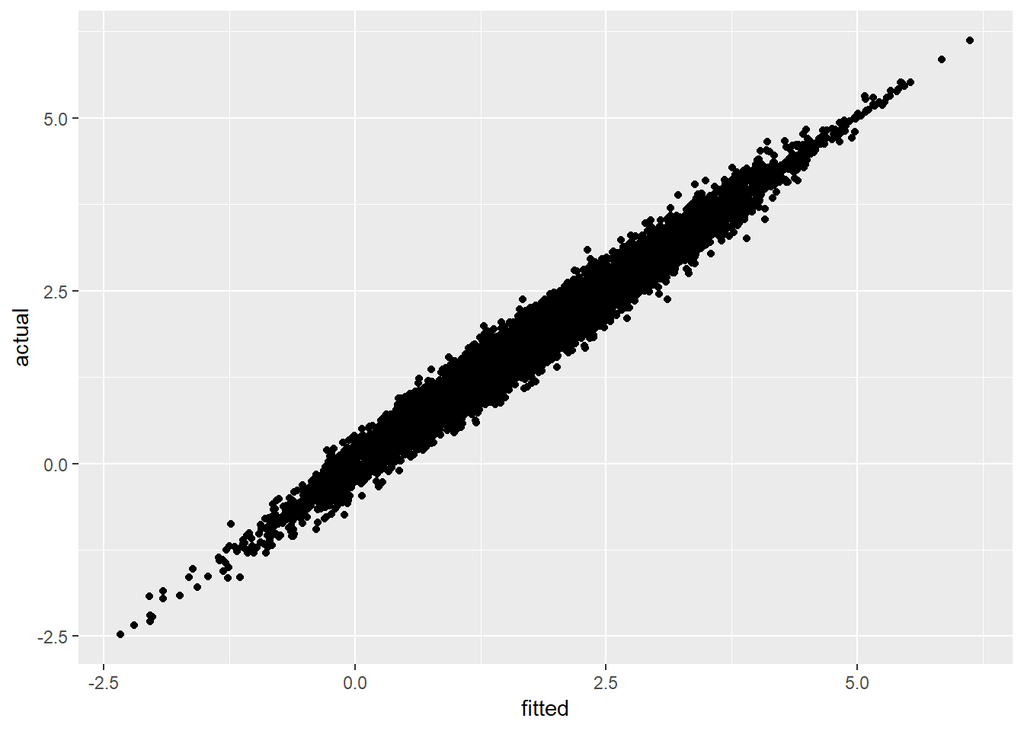

```r
library(ggplot2)
df<-data.frame(fitted=fitted(pl),actual=df_T$y_error)
ggplot(df, aes(fitted, actual))+geom_point()
```

```r
#+ scale_x_continuous(breaks=seq(-2.5, 5.0, 2.5))+ scale_y_continuous(breaks=seq(-2.5, 5.0, 2.5))
```

4. Check that $\beta_l$ is not identified with the data without optimization error. Estimate the first stage model of Olley-Pakes with the labor choice without optimization error and report the result.

```r
bw2 <- npplregbw(formula=y~l + k+I|k+I, data = df_T)
```

[output not shown]

[output cut: 11 more lines]

[output not shown]

```r
pl2 <- npplreg(bws=bw2)
summary(pl2)
```

```
##
## Partially Linear Model
## Regression data: 10000 training points, in 5 variable(s)
## With 3 linear parametric regressor(s), 2 nonparametric regressor(s)
##
##                     y(z)
## Bandwidth(s): 0.07347226 0.01437256
##
##                     x(z)
## Bandwidth(s): 0.02960021 0.009986945
##               0.01397428 3.749530394
##               0.83529394 0.003983290
##
##                        l        k         I
## Coefficient(s): 1.180628 2.034182 0.7805075
##
## Kernel Regression Estimator: Local-Constant
## Bandwidth Type: Fixed
##
## Residual standard error: 0.1932285
## R-squared: 0.970116
##
## Continuous Kernel Type: Second-Order Gaussian
## No. Continuous Explanatory Vars.: 2
```

Then, we estimate the second stage model of Olley-Pakes method:

$$y_{jt} - \hat{\beta_l} l_{jt} = \beta_0 + \beta_k k_{jt} + \alpha[\hat{\phi}(k_{j, t - 1}, I_{j, t - 1}) - \beta_0 - \beta_k k_{jt}] + \nu_{jt} + \eta_{jt}.$$

In this model, we do not have to non-parametetrically estimate the conditional expectation of $\omega_{jt}$ on $\omega_{j,t-1}$ because we know that the anticipated shock follows an AR(1) process. Remark that we in general have to non-parametrically estimate it.

The model is non-linear in parameters, because of the term $\alpha \beta_0$ and $\alpha \beta_k$. We estimate $\alpha$ and $\beta_o$ and $\beta_k$ by a GMM estimator. The moment is:

$$g_{JT}(\alpha, \beta_0, \beta_k) \equiv \frac{1}{JT}\sum_{j = 1}^J \sum_{t = 1}^T \{y_{jt} - \hat{\beta_l} l_{jt} - \beta_0 - \beta_k k_{jt} - \alpha[\hat{\phi}(k_{j, t - 1}, I_{j, t - 1}) - \beta_0 - \beta_k k_{jt}]\} \begin{bmatrix}k_{jt} \\k_{j, t - 1} \\I_{j, t - 1}\end{bmatrix}.$$

5. Using the estimates in the first step, compute:

$$y_{jt} - \hat{\beta_l} l_{jt},$$

and

$$\hat{\phi}(k_{j, t - 1}, I_{j, t - 1}),$$

for each $j$ and $t$ and save it as a data frame names df_T_1st.

```r
df_T_1st<-tibble(j=df_T$j, t=df_T$t, y_error_tilde=df_T$y_error-coefficients(pl)[1]*df_T$l_error,residual=residuals(pl))
df_T_1st<- df_T_1st %>%
  dplyr::group_by(j) %>%
  dplyr::mutate(phi_t_1=lag(y_error_tilde-residual,1)) %>%
  dplyr::ungroup()
#df_T_1st$phi_t_1=lag(df_T_1st$y_error_tilde-residuals(pl),1)
df_T_1st<-df_T_1st[order(df_T_1st$j,df_T_1st$t),]
```

```r
moment=moment_OP_2nd(df_T,df_T_1st,alpha,beta_0,beta_k)
moment
```

[output not shown]

Based on the moment, we can define the objective function of a generalized method of moments estimator with a weighting matrix $W$ as:

$$Q_{JT}(\alpha, \beta_0, \beta_k) \equiv g_{JT}(\alpha, \beta_0, \beta_k)' W g_{JT}(\alpha, \beta_0, \beta_k).$$

7. Write a function that returns the value of $Q_{JT}(\alpha, \beta_0, \beta_k)$ given the vector of parameter values, data, and `df_T_1st`, and name it `objective_OP_2nd`. Setting $W$ at the identity matrix, show the value of the objective function evaluated at the true parameters.

```r
objective=objective_OP_2nd(df_T,df_T_1st,alpha,beta_0,beta_k)
objective
```

```
## [1] 0.0003805598
```

8. Draw the graph of the objective function when one of $\alpha$, $\beta_0$ and $\beta_k$are changed from 0 to 1 by 0.1 while the others are set at the true value.

```r
library(latex2exp)
library(foreach)
```

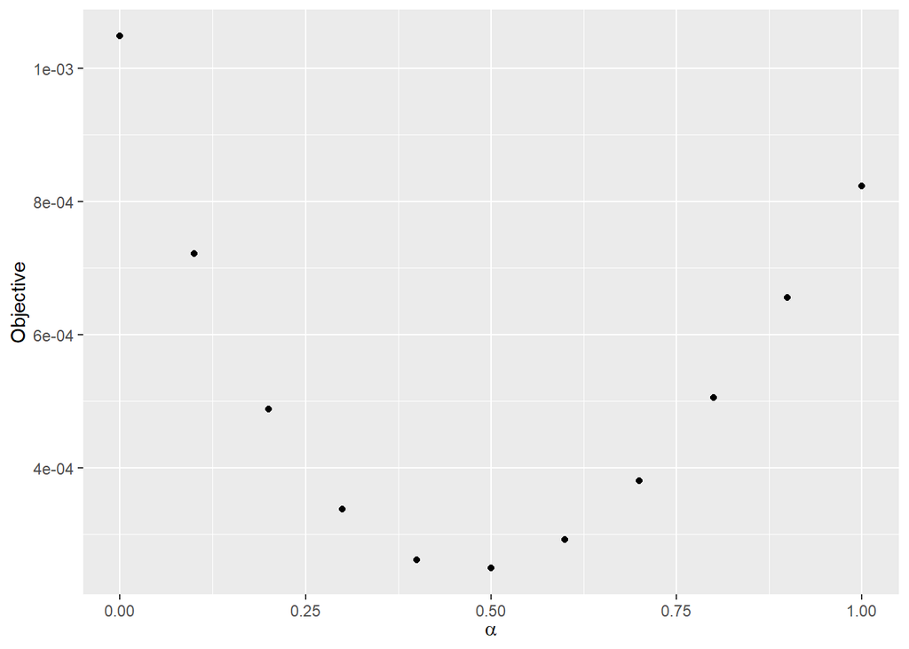

```r
output1<-foreach(alp=seq(0,1,0.1),.combine="rbind") %do%{
  a=objective_OP_2nd(df_T,df_T_1st,alp,beta_0,beta_k)
  return(a)
}
qplot(seq(0,1,0.1),output1,xlab=TeX('$\\alpha'), ylab="Objective")
```

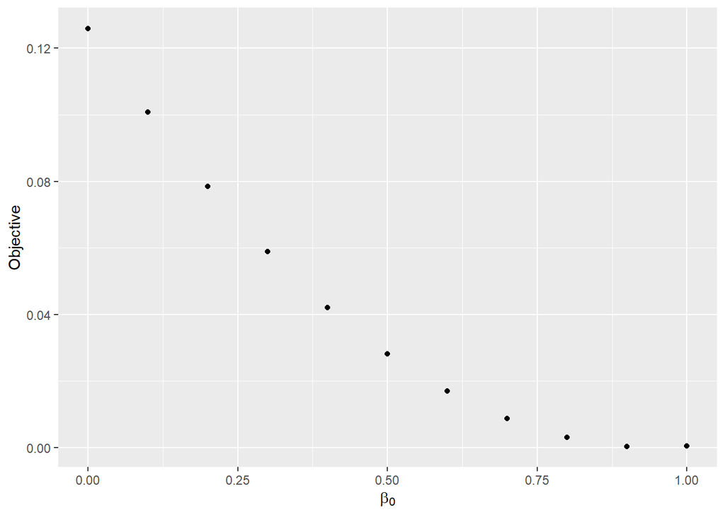

```r
output2<-foreach(bta=seq(0,1,0.1),.combine="rbind") %do%{
  b=objective_OP_2nd(df_T,df_T_1st,alpha,bta,beta_k)
  return(b)
}
qplot(seq(0,1,0.1),output2,xlab=TeX('$\\beta_0'), ylab="Objective")
```

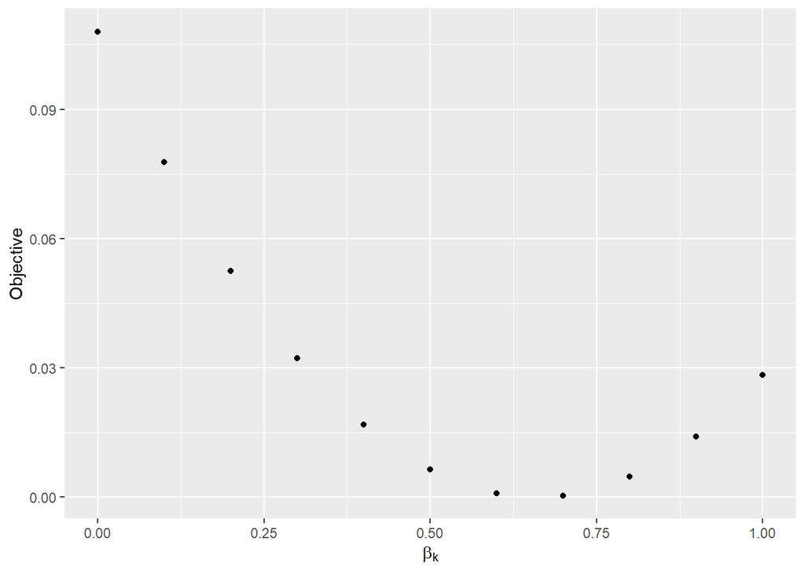

```r
output3<-foreach(btak=seq(0,1,0.1),.combine="rbind") %do%{
  c=objective_OP_2nd(df_T,df_T_1st,alpha,beta_0,btak)
  return(c)
}
qplot(seq(0,1,0.1),output3,xlab=TeX('$\\beta_k'), ylab="Objective")
```

9. Find the parameters that minimize the objective function using `optim`. I use `L-BFGS-B` method to solve it.

```r
minf<-function(opp){objective_OP_2nd(df_T,df_T_1st,alpha=opp[1],beta_0=opp[2],beta_k=opp[3])}
optim(par=c(0.1,0.1,0.1), fn=minf,method="L-BFGS-B")
```

```
## $par
## [1] 0.9616832 0.5064036 0.6406066
##
## $value
## [1] 1.350668e-05
##
## $counts
## function gradient
##        7        7
##
## $convergence
## [1] 0
##
## $message
## [1] "CONVERGENCE: REL_REDUCTION_OF_F <= FACTR*EPSMCH"
```